# Temperature Sensitivty in New Englands's ISO

Kai van Loon, Kevin Vu , Talya Ghert, Arisa Srisuthisuriya

```python
import pandas as pd
import matplotlib.pyplot as plt
import numpy as np
import seaborn as sns
import statsmodels.api as sm
import sklearn
import altair as alt
import matplotlib
from sklearn.model_selection import train_test_split
from sklearn.linear_model import LinearRegression
from lineartree import LinearTreeRegressor
import matplotlib.pyplot as plt
from joypy import joyplot
from sklearn.tree import DecisionTreeRegressor




%matplotlib inline
```

### 2. Spillover Effects

- Generation Mix
- Gas Load
- Gas Prices
- Conclusion and Policy Implications

### 1. Background and Temperature Sensitivity

#### Context

Electricity grids use a "merit order model" or "supply stack" to determine prices. Different generators, each with their own marginal cost, "stack" along the supply curve until demand is met, setting the price. This means that at any given time, the grid operates with a mix of generation sources—such as natural gas, hydro, solar, nuclear, biomass, and wind—each contributing a percentage of the total electricity. Some of these generation sources are more weather-dependent, making electricity grids correlated with weather and temperature fluctuations.

Our project is motivated by Shaffer, Quintero and Rhodes, 2022.

In their paper, the authors determine that in Texas, temperature sensitivity increased over the past two decades. During the cold snap of 2021, an additional 8% of power demand was attributed to this evolving temperature sensitivity. We aim to investigate whether other ISOs/RTOs across the country exhibit similar time-varying temperature sensitivity. Our focus will be on New England’s Independent System Operator (ISO-NE). A key difference between the New England context and that of Texas, as studied by Shaffer, Quintero, and Rhodes (2022), is that Texas's heating relies mostly on electricity, while in New England, heating is predominantly powered by heating oil and natural gas. This creates an intriguing context to study temperature sensitivity, as the degree of sensitivity and the share of electricity-powered heating are likely correlated.

Our project will be divided into two sections. First, we will model temperature sensitivity using:

A linear tree regression, and a binned temperature regression, to observe changes from 2011 to 2017. Next, we will examine potential spillover effects in the power market, focusing on whether cold-weather heating demand affects the volume of natural gas dispatched on the grid. We hypothesize that additional demand for heating oil and natural gas-powered heating (which are separate markets from electricity) influences natural gas prices. These price changes, in turn, affect electricity generators using natural gas.

As the energy transition progresses, understanding temperature sensitivity in regions still heavily reliant on fossil fuels will be critical for policymakers and electricity market design.

#### Data

We use data directly from ISO-NE's [website](https://www.iso-ne.com/isoexpress/). ISO-NE is divided into 8 load zones, and hourly price, demand and temperature data is given at the load zone level.

```python
states = ['ISONE CA', 'ME', 'NH', 'VT', 'CT', 'RI', 'SEMASS' ,'WCMASS', 'NEMASSBOST']

state_dfs = [pd.DataFrame(columns=['Date', 'Hour', 'DA Demand', 'RT Demand',
                                   'DA Price', 'RT Price', 'Temperature', 'Region']) for _ in states]

state_names = ['isone_ca', 'me', 'nh', 'vt', 'ct', 'ri', 'sema', 'wcma', 'nema']

state_names_full = ['ISO-NE Control Area', 'Maine', 'New Hampshire', 'Vermont',
                    'Connecticut', 'Rhode Island', 'SouthEastern Massachusetts',
                    'Western & Central Massachusetts', 'NorthEastern Massachusetts & Boston']
```

```python
for i in range(len(state_names)):
    path = f"/Users/kaivanloon/Desktop/local_data/local_demand/{state_names[i]}.csv"
    state_dfs[i] = pd.read_csv(path)
    state_dfs[i]["Date"] = pd.to_datetime(state_dfs[i]["Date"])
```

```python
state_dfs[0].head()
```

|  | Year | Region | Date | Hour | DA Demand | RT Demand | DA Price | RT Price | Temperature |
| --- | --- | --- | --- | --- | --- | --- | --- | --- | --- |
| 0 | 2011 | ISO-NE Control Area | 2011-01-01 | 1 | 11722.0 | 12055.0 | 38.51 | 41.57 | 36 |
| 1 | 2011 | ISO-NE Control Area | 2011-01-01 | 2 | 11253.0 | 11430.0 | 36.86 | 34.91 | 36 |
| 2 | 2011 | ISO-NE Control Area | 2011-01-01 | 3 | 10459.0 | 10966.0 | 35.92 | 35.46 | 35 |
| 3 | 2011 | ISO-NE Control Area | 2011-01-01 | 4 | 10531.0 | 10725.0 | 35.94 | 34.14 | 35 |
| 4 | 2011 | ISO-NE Control Area | 2011-01-01 | 5 | 10841.0 | 10672.0 | 36.05 | 33.63 | 36 |

We take natural gas data from the [Energy Information Administration](https://www.eia.gov/dnav/ng/ng_pri_sum_a_EPG0_PG1_DMcf_m.htm) (EIA). ISO-NE relies heavily on natural gas to power generators and so we test if large changes in the price of natural gas have some degree of effect on the power prices. The citygate price in the dataframe below is the point of intersection between the mainline transmssion syste and the local distribution system for the respective state. Unlike hub prices (think Henry, Hub, SoCal, Station 2) which are prices relvant for traders, the citygate price represents the price paid for by utility and heating companies, thus making it the most relevant benchmark for our project.

```python
ng = pd.read_excel('/Users/kaivanloon/Desktop/local_data/NG_PRI_SUM_A_EPG0_PG1_DMCF_M.xls', sheet_name = 'Data 1',
                   skiprows = 2)

ng = ng[['Date', 'Natural Gas Citygate Price in Connecticut (Dollars per Thousand Cubic Feet)',
         'Natural Gas Citygate Price in Maine (Dollars per Thousand Cubic Feet)',
         'Natural Gas Citygate Price in Massachusetts (Dollars per Thousand Cubic Feet)',
         'Natural Gas Citygate Price in New Hampshire (Dollars per Thousand Cubic Feet)',
         'Natural Gas Citygate Price in Rhode Island (Dollars per Thousand Cubic Feet)',
         'Natural Gas Citygate Price in Vermont (Dollars per Thousand Cubic Feet)']]

ng.columns = ['Date', 'Connecticut', 'Maine', 'Massachusetts', 'New Hampshire', 'Rhode Island', 'Vermont']

ng = ng[(ng['Date'] >= '2011-01-01') & (ng['Date'] <= '2017-12-31')]

ng['year_month'] = ng['Date'].dt.to_period('M')

ng.head()
```

|  | Date | Connecticut | Maine | Massachusetts | New Hampshire | Rhode Island | Vermont | year_month |
| --- | --- | --- | --- | --- | --- | --- | --- | --- |
| 456 | 2011-01-15 | 5.74 | 7.59 | 6.70 | 8.06 | 7.82 | 7.60 | 2011-01 |
| 457 | 2011-02-15 | 5.93 | 7.24 | 6.90 | 7.22 | 7.62 | 7.72 | 2011-02 |
| 458 | 2011-03-15 | 5.66 | 8.65 | 6.57 | 8.30 | 7.03 | 8.04 | 2011-03 |
| 459 | 2011-04-15 | 5.87 | 7.53 | 7.25 | 7.72 | 7.09 | 8.69 | 2011-04 |
| 460 | 2011-05-15 | 6.67 | 9.97 | 7.84 | 7.95 | 9.80 | 8.87 | 2011-05 |

```python
for i in range(len(state_dfs)):
    state_dfs[i]['year_month'] = state_dfs[i]['Date'].dt.to_period('M')
    #All New England - no NG price data
    if i == 0:
        state_dfs[i].drop(columns = ['year_month'], inplace = True)
        continue
    #Maine
    elif i == 1:
        state_dfs[i] = pd.merge(state_dfs[i], ng[['year_month', 'Maine']], on = 'year_month', how = 'left')
        state_dfs[i] = state_dfs[i].rename(columns={'Maine': 'Natural Gas Price'})
    #New Hampsphire
    elif i == 2:
        state_dfs[i] = pd.merge(state_dfs[i], ng[['year_month', 'New Hampshire']], on = 'year_month', how = 'left')
        state_dfs[i] = state_dfs[i].rename(columns={'New Hampshire': 'Natural Gas Price'})
    #Vermont
    elif i == 3:
        state_dfs[i] = pd.merge(state_dfs[i], ng[['year_month', 'Vermont']], on = 'year_month', how = 'left')
        state_dfs[i] = state_dfs[i].rename(columns={'Vermont': 'Natural Gas Price'})
    #Connecticut
    elif i == 4:
        state_dfs[i] = pd.merge(state_dfs[i], ng[['year_month', 'Connecticut']], on = 'year_month', how = 'left')
        state_dfs[i] = state_dfs[i].rename(columns={'Connecticut': 'Natural Gas Price'})
    #Rhode Island
    elif i == 5:
        state_dfs[i] = pd.merge(state_dfs[i], ng[['year_month', 'Rhode Island']], on = 'year_month', how = 'left')
        state_dfs[i] = state_dfs[i].rename(columns={'Rhode Island': 'Natural Gas Price'})
    #Massachusetts
    else:
        state_dfs[i] = pd.merge(state_dfs[i], ng[['year_month', 'Massachusetts']], on = 'year_month', how = 'left')
        state_dfs[i] = state_dfs[i].rename(columns={'Massachusetts': 'Natural Gas Price'})
    state_dfs[i].drop(columns = ['year_month'], inplace = True)
```

We can plot real time (RT) power demand against temperature to get a sense of what the temperature response fucntions look like across the New England ISO. The below plot represents the entire ISO for 2011-2017.

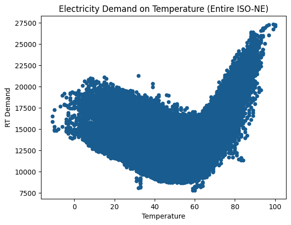

```python
state_dfs[0].plot.scatter('Temperature', 'RT Demand', color = '#185c90')
plt.title('Electricity Demand on Temperature (Entire ISO-NE)')
```

Now we do it for all load zones.

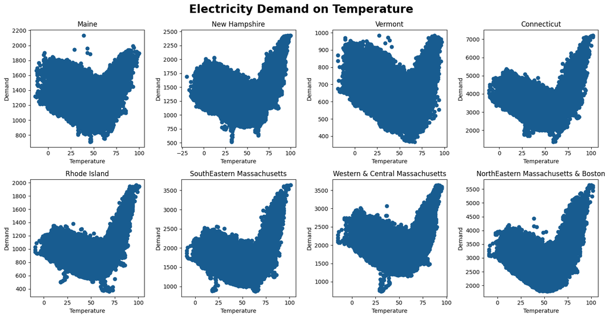

```python
fig, axes = plt.subplots(2, 4, figsize=(15, 8))
axes = axes.flatten()

for i, (df, name) in enumerate(zip(state_dfs[1:], state_names_full[1:])):
    axes[i].scatter(df['Temperature'], df['RT Demand'], color = '#185c90')
    axes[i].set_title(name)
    axes[i].set_ylabel('Demand')
    axes[i].set_xlabel('Temperature')

fig.suptitle('Electricity Demand on Temperature', fontsize=20, fontweight='bold')


# Adjust layout to prevent overlap
plt.tight_layout()
plt.show()
```

We notice that our plots are very *asymetrical*. Sensitivity is relatively high on the right hand side, where temperature is increasing. On the left hand side, large dips in temperature don't result in as much change in power demanded.

This makes sense in the context of New England. Here, heating is mostly powered by natural gas and heating oil and so cold spells won't have a huge effect on power demand, because *most people don't need power to heat their homes*.

In order to capture this asymetry, we use a linear tree method which segments the function, rather than something like a quadratic.

#### Linear Tree Regression

In our context, the advantage of using a linear tree regression is that it allows us to capture the demand nadir, without having to impose it. We use a linear tree aproach with a max depth of 1 to model not only the asymetries found in the NE demand-temperature scatter but also to capture the minimum point -- the temperature level that induces the least amount of power demanded.

$$ argmax_{\alpha, \beta} \sum_{X_i < R} (y_i - X'_i \beta)^2 + \sum_{X_i >= R} (y_i - X'_i \alpha)^2 $$

Where $\alpha$ and $\beta$ represent the slope parameters for either side of the piecewise regression and $R$ is the nadir.

Below, we run it for each year in our dataset: 2011 to 2017.

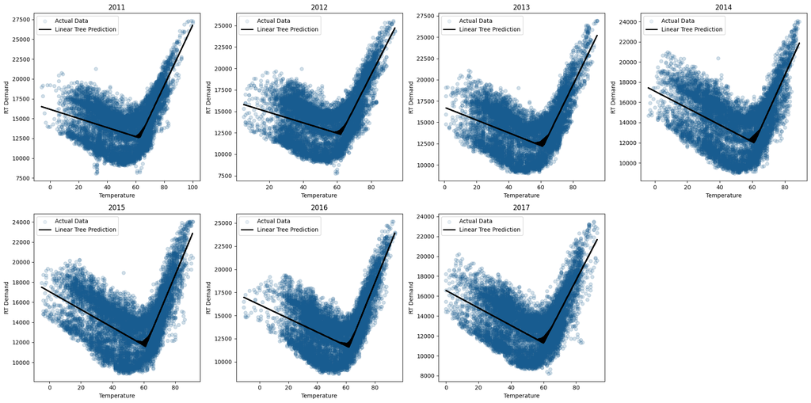

```python
state_dfs[0]['Year'] = state_dfs[0]['Date'].dt.year

unique_years = [2011, 2012, 2013, 2014, 2015, 2016, 2017]
# plotting for viewing
rows, cols = 2, 4
fig, axes = plt.subplots(rows, cols, figsize=(20, 10))
axes = axes.flatten()

# Loop for each year
for idx, year in enumerate(unique_years):


    # loop through for each year
    df_year = state_dfs[0][state_dfs[0]['Year'] == year]


    X = df_year[['Temperature']]
    y = df_year['RT Demand']


    X_train, X_test, y_train, y_test = train_test_split(X, y, test_size=0.2, random_state=42)

    # initiliaze linear tree regressor
    base_estimator = LinearRegression()
    model = LinearTreeRegressor(
        base_estimator=base_estimator,
        criterion='mse',
        max_depth=1,
        min_samples_split=6,
        min_samples_leaf=0.1,
        max_bins=25,
    )

    # training
    model.fit(X_train, y_train)

    # Make predictions on the full dataset
    y_pred = model.predict(X)

    # plotting
    ax = axes[idx]
    ax.scatter(df_year['Temperature'], df_year['RT Demand'], color='#185c90', label='Actual Data', alpha=0.1)
    ax.plot(df_year['Temperature'], y_pred, color='black', linewidth=2, label='Linear Tree Prediction')
    ax.set_title(f'{year}')
    ax.set_xlabel('Temperature')
    ax.set_ylabel('RT Demand')
    ax.legend()

# Remove the bottom right subplot
for i in range(len(unique_years), len(axes)):
    fig.delaxes(axes[i])

# Adjust layout
plt.tight_layout()
plt.show()
```

Here, the slope represents the *degree of sensitivity*. Has it changed over time? We overlay the plots from 2011, 2014 and 2017 to see. Please note that we are interested in the left hand side of the graph only, as sensitivity that pertains to cold temperatures is what we are testing here.

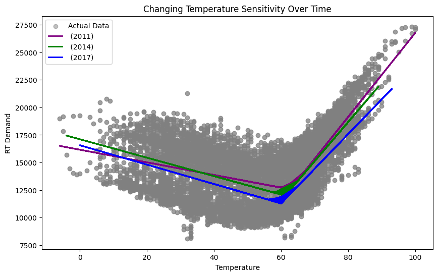

```python
selected_years = [2011, 2014, 2017]


plt.figure(figsize=(10, 6))
colors = ['purple', 'green', 'blue']

# loop through
for idx, year in enumerate(selected_years):

    df_year = state_dfs[0][state_dfs[0]['Year'] == year]
    X = df_year[['Temperature']]
    y = df_year['RT Demand']

    # same as before
    X_train, X_test, y_train, y_test = train_test_split(X, y, test_size=0.2, random_state=42)

    base_estimator = LinearRegression()
    model = LinearTreeRegressor(
        base_estimator=base_estimator,
        criterion='mse',
        max_depth=1,
        min_samples_split=6,
        min_samples_leaf=0.1,
        max_bins=25,
        categorical_features=None,
        split_features=None,
        linear_features=None,
        n_jobs=None
    )
    model.fit(X_train, y_train)
    y_pred = model.predict(X)

    # add the scatter for just that year
    if idx == 0:
        plt.scatter(df_year['Temperature'], df_year['RT Demand'], color='gray', alpha=0.5, label='Actual Data')

    # plot for each year
    plt.plot(df_year['Temperature'], y_pred, color=colors[idx], linewidth=2, label=f' ({year})')

plt.xlabel('Temperature')
plt.ylabel('RT Demand')
plt.title('Changing Temperature Sensitivity Over Time')
plt.legend()


plt.show()
```

We see that sensitivity has increased from 2011 to 2014 but seems to have plateaued from 2014 onwards. However, the plots from 2014 and 2017 seem to have very similar slopes.

```python
iso_df_tree = state_dfs[0]

# dictionary for calling
plots_ISO_tree = {}

# Loop through all years
for year in range(2011, 2018):
    year_df = iso_df_tree[iso_df_tree['Date'].dt.year == year]

    X = year_df[['Temperature']].values
    y = year_df['RT Demand'].values


    tree_clf = DecisionTreeRegressor(max_depth=5)
    tree_clf.fit(X, y)

    # generate appropriate predictions
    x_pred = np.linspace(year_df['Temperature'].min(), year_df['Temperature'].max(), 100).reshape(-1, 1)
    y_tree_pred = tree_clf.predict(x_pred)

    # plotting
    pred_df = pd.DataFrame({
        'Temperature': x_pred.flatten(),
        'RT Demand': y_tree_pred,
        'Year': [year] * len(x_pred)
    })

    # plotting charactersitics
    plot = alt.Chart(pred_df).mark_line().encode(
        x='Temperature:Q',
        y='RT Demand:Q',
    ).properties(
        title=f'Temperature Response Function -- ISO-NE ({year})',
        width=360,  # smaller width to fit 3 per row
        height=250  # smaller height to fit 3 per row
    )

    # Store the plot in the dictionary
    plots_ISO_tree[year] = plot

# Group the plots into rows with 3 per row (using hconcat for horizontal concatenation)
row_1 = alt.hconcat(plots_ISO_tree[2011], plots_ISO_tree[2012], plots_ISO_tree[2013], plots_ISO_tree[2014])
row_2 = alt.hconcat(plots_ISO_tree[2015], plots_ISO_tree[2016], plots_ISO_tree[2017])

# Combine the rows vertically
combined_plot = alt.vconcat(row_1, row_2)

# Display the combined plot
combined_plot.show()
```

[interactive chart not shown]

We can see how these temperature response functions have changed over time by overlaying the 2011, 2014 and 2017 plots.

```python
iso_df_tree = state_dfs[0]

# Prepare an empty list to store prediction dataframes for selected years
selected_years = [2011, 2014, 2017]
overlay_data = []

for year in selected_years:
    #filter through
    year_df = iso_df_tree[iso_df_tree['Date'].dt.year == year]

    X = year_df[['Temperature']].values
    y = year_df['RT Demand'].values

    tree_clf = DecisionTreeRegressor(max_depth=5)
    tree_clf.fit(X, y)

    x_pred = np.linspace(year_df['Temperature'].min(), year_df['Temperature'].max(), 100).reshape(-1, 1)
    y_tree_pred = tree_clf.predict(x_pred)

    # new plotting df
    pred_df = pd.DataFrame({
        'Temperature': x_pred.flatten(),
        'RT Demand': y_tree_pred,
        'Year': [year] * len(x_pred)
    })
    overlay_data.append(pred_df)

# combine the three
overlay_data_combined = pd.concat(overlay_data)

# overlayed
overlay_plot = alt.Chart(overlay_data_combined).mark_line().encode(
    x=alt.X('Temperature:Q', title='Temperature'),
    y=alt.Y('RT Demand:Q', title='RT Demand'),
    color=alt.Color('Year:N', legend=alt.Legend(title='Year'))
).properties(
    title='Changing Temperature Sensitivty Over Time',
    width=600,
    height=400
)

# Display the combined plot
overlay_plot.show()
```

[interactive chart not shown]

#### Binned-Temperature Regression

In addition to running the linear tree fit, we also try to approximate our temperature response function by adopting the approach taken by Shaffer, Quintero and Rhodes, 2022, as well as other existing literature( [Wenz, et al, 2017](https://www.pnas.org/doi/abs/10.1073/pnas.1704339114), [Auffhammer et al., 2017](https://www.pnas.org/doi/abs/10.1073/pnas.1613193114) ). This approach is useful because it allows us to capture non-linearities: We expect the same 3 degree change to result in a far large demand change in the outer limits of our function.

We will run the following regression:

$$ \log \text{Load}_{t,z} = \sum_{b} \beta_{b,z} \text{Temp}_{bt,z} + \theta_{z} X_{t,z} + \epsilon_{t,z} $$

Where:

- The **Dependent Variable** is $\log \text{Load}_{t,z}$. This is the logarithmic function of hourly electricity load $y$ in zone $z$ at time $t$.

Log-transformation will allow us to interpret the $\log \text{Load}_{t,z}$ change as a percentage changes.

- The **Residual Variable** $\epsilon_{t,z}$ captures unexplained variation in electricity demand after accounting for temperature and fixed effects.

We first run the regression for the ISO-NE region.

```python
# filtering for entire ISO
iso_df = state_dfs[0]

# Create bins for temperature
bin_width = 3
iso_df['Temp'] = np.floor(iso_df['Temperature'] / bin_width) * bin_width

baseline_bin = 40

# Create dummies for bins
temp_dummies = pd.get_dummies(iso_df['Temp'], prefix='Temp')

# Ensure the baseline bin is included, even if it has no observations
if f'Temp_{baseline_bin}' not in temp_dummies.columns:
    temp_dummies[f'Temp_{baseline_bin}'] = 0

# Drop baseline
temp_dummies.drop(f'Temp_{baseline_bin}', axis=1, inplace=True)

# Concat the two df
iso_df = pd.concat([iso_df, temp_dummies], axis=1)

# Remove bins with less than ten observations (per the paper)
valid_bins = temp_dummies.columns[iso_df.groupby(temp_dummies.columns.tolist()).size() >= 10]
iso_df = iso_df[iso_df[valid_bins].sum(axis=1) > 0]

# Define the dependent variable (log of hourly electricity demand)
iso_df['Log_Demand'] = np.log(iso_df['RT Demand'])
y = iso_df['Log_Demand']

# Dictionary to store the plots by year
plots_ISO = {}

for year in range(2011, 2018):
    # filter
    year_df = iso_df[iso_df['Date'].dt.year == year]

    independent_vars = valid_bins.tolist() + [
        col for col in year_df.columns if col.startswith(('Year_FE_', 'Month_FE_', 'DayOfWeek_FE_', 'Hour_FE_'))
    ]
    X = year_df[independent_vars]

    # run for each year
    X = sm.add_constant(X)
    model = sm.OLS(y[year_df.index], X.astype(float)).fit()

    # group by bins
    binned_data = year_df.groupby('Temp')['RT Demand'].mean().reset_index()
    binned_data.rename(columns={'RT Demand': 'Demand'}, inplace=True)

    # altair plot
    alt_temp_response = alt.Chart(binned_data).mark_line().encode(
        x='Temp:Q',
        y='Demand:Q'
    ).properties(
        title=f'Temperature Response Function -- ISO-NE ({year})', width = 360, height = 250
    )

    # Store the plot in the dictionary
    plots_ISO[year] = alt_temp_response

row_1 = alt.hconcat(plots_ISO[2011], plots_ISO[2012], plots_ISO[2013], plots_ISO[2014])
row_2 = alt.hconcat(plots_ISO[2015], plots_ISO[2016], plots_ISO[2017])

# combine
combined_plot = alt.vconcat(row_1, row_2)

# Display the combined plot
combined_plot.show()
```

[interactive chart not shown]

Has sensitivity *changed over time?* To look at this, we overlay plots from the entire ISO for 2011, 2014 and 2017. The grey indicates 2011, the light blue 2014 and the dark blue 2017.

```python
plot_2011 = plots_ISO[2011]
plot_2014 = plots_ISO[2014]
plot_2017 = plots_ISO[2017]

plot_2011 = plot_2011.encode(color=alt.value('lightgrey'), opacity=alt.value(0.5))
plot_2014 = plot_2014.encode(color=alt.value('lightblue'), opacity=alt.value(.9))
plot_2017 = plot_2017.encode(color=alt.value('darkblue'), opacity=alt.value(1.0))

# Combing
combined_plot = alt.layer(
    plot_2011,
    plot_2017,
    plot_2014
).properties(
    title='Changing Temperature Sensitivity Over Time', width = 600, height = 400
)
combined_plot.show()
```

[interactive chart not shown]

### 2. Spillover Effects

By looking at our regression results, we can reasonably say that we do not see the same levels of changing temperature sensitivity over time, unlike Shaffer, Quintero and Rhodes, 2022. This also likely means that we will not see that much spillover from temperature sensitivity to power generation. Even though *both heating and power* in New England largely rely on natural gas, low temperature sensitivity for cold temperature means that spillovers will be minimal.

In this next section, we will look at some of the key indicators that help illustrate this.

#### Generation Mix

Again, we use data from ISO-NE's [website](https://www.iso-ne.com/isoexpress/web/reports/operations/-/tree/daily-gen-fuel-type). This data is at the daily level and shows the percentage of each generation source. At a high level, generation mix is determined by at least two things:

1. Temperature: Some sources of energy are more *sensitive to weather patterns*. For example, a solar panel cannot produce at night, while a gas generator can produce, no matter the time of day.
2. Demand: When demand is high enough, or peaking additional generators are often turned on to satisfy these high load demands. These plants are often called **peaking power plants** and are typically turned on during high periods of daily load (7:00-9:00 and 17:00-20:00) or during periods of *extreme temperature*.

By looking at how generation mix changes with temperature, we can get a better idea of when exactly these peaking power plants come online.

We load and clean data and create both a nominal load source and percentage load df.

```python
dataframes_genmix = []
pct_data = []

for year_genmix in range(2011, 2018):
    data_path_genmix = f"/Users/kaivanloon/Desktop/local_data/gen_mix/{year_genmix}_daygenbyfuel.xlsx"
    sheet = "POST-EMOF Fuel Types" if year_genmix <= 2013 else "POST-EMOF Gen_w_Blending"

    genmix_df = pd.read_excel(data_path_genmix, sheet_name=sheet)

    genmix_df = genmix_df.dropna(subset=['DATE'])
    genmix_df['DATE'] = pd.to_datetime(genmix_df['DATE'], format='%m/%d/%Y', errors='coerce')

    dataframes_genmix.append(genmix_df)

    #create the pct df
    genmix_pct = genmix_df.copy()

    for col in genmix_pct.columns:
        if col != 'DATE':
            genmix_pct[col] = genmix_pct[col] / genmix_pct['TOTAL'] * 100

    pct_data.append(genmix_pct)


#Fuel Data
final_genmix_df = pd.concat(dataframes_genmix, ignore_index=True)
final_genmix_df.columns = [col.title() for col in final_genmix_df.columns]
final_genmix_df = final_genmix_df.drop(columns = ['Total'])

#Percentage Data
genmix_pct = pd.concat(pct_data, ignore_index=True)
genmix_pct = genmix_pct.drop(columns = ['TOTAL', 'OTHER', 'STEAM'])
genmix_pct.columns = [col.title() for col in genmix_pct.columns]
genmix_pct.columns = [col + " Percentage" if col != 'Date' else col for col in genmix_pct.columns]
```

With this new percentage generation mix data frame, we can visualize how sources of power have changed over time.

However, using data at the daily level is too granular. Instead, we create a new df for monthly observations and look at generation trends over time for 2011-2017. We do this for both the percentage and nominal data.

```python
# percentage
genmix_pct['year_month'] = genmix_pct['Date'].dt.to_period('M')

# calculate the mean
monthly_genmix_pct = (
    genmix_pct.groupby('year_month')
    .mean(numeric_only=True)
    .reset_index()
)
monthly_genmix_pct['year_month'] = monthly_genmix_pct['year_month'].dt.to_timestamp()

# nominal
final_genmix_df['year_month'] = final_genmix_df['Date'].dt.to_period('M')

# calculate the mean
monthly_genmix_nom = (
    final_genmix_df.groupby('year_month')
    .mean(numeric_only=True)
    .reset_index()
)
monthly_genmix_nom['year_month'] = monthly_genmix_nom['year_month'].dt.to_timestamp()
```

```python
alt.data_transformers.enable('default', max_rows=None)

# melt to put into altair
monthly_genmix_long = monthly_genmix_pct.melt(
    id_vars=['year_month'],
    var_name='Source',
    value_name='Percentage'
)

# plot chart
chart = alt.Chart(monthly_genmix_long).mark_area().encode(
    x=alt.X('year_month:T', title='Month', axis=alt.Axis(format='%b %Y')),
    y=alt.Y('Percentage:Q', title='Generation Percentage', stack='normalize'),
    color=alt.Color('Source:N', title='Energy Source'),
    tooltip=[
        alt.Tooltip('year_month:T', title='Month'),
        alt.Tooltip('Source:N', title='Energy Source'),
        alt.Tooltip('Percentage:Q', title='Percentage', format='.2f')
    ]  # Adding tooltips
).properties(
    title='Monthly Generation Mix - By Percentage Source',
    width=800,
    height=400
)
chart
```

[interactive chart not shown]

We notice that Gas and Nuclear are the largest sources of generation. Keeping in mind that we suspect colder temperatures will affect generation mix, we next plot gas generation over the same period.

```python
gas_pct_monthly = monthly_genmix_pct[['year_month', 'Gas Percentage']]

# create line chart just for gas
chart = alt.Chart(gas_pct_monthly).mark_line().encode(
    x=alt.X('year_month:T', title='Month', axis=alt.Axis(format='%b %Y')),
    y=alt.Y('Gas Percentage:Q', title='Gas Percentage (%)'),

).properties(
    title='Percentage Gas Generation by Month',
    width=800,
    height=400
)
chart
```

[interactive chart not shown]

Here, we see consistent lows in the the percentage of gas in generation mix when temperatures get low (during December, January and Febuary).

To be sure of this, we overlay daily temperature to be sure they travel together. The graph below contains both the mean temperature (in fahrenheit) as well as the mean monthly percentage of gas in the generation mix. This graph works out nicely because we use *two different units* (F and gas %) but just one axis.

```python
temperature_df = state_dfs[0][['Date', 'Temperature']].copy()
# aggregate monthly
temperature_df['year_month'] = temperature_df['Date'].dt.to_period('M').dt.to_timestamp()

# take mean
monthly_temperature = (
    temperature_df.groupby('year_month')['Temperature']
    .mean()
    .reset_index()
)
# overlay gas and temp
overlay_df = pd.merge(
    monthly_genmix_pct[['year_month', 'Gas Percentage']],
    monthly_temperature,
    on='year_month'
)
# melt for altair
overlay_long = overlay_df.melt(
    id_vars=['year_month'],
    var_name='Variable',
    value_name='Value'
)

gas_temp = alt.Chart(overlay_long).mark_line().encode(
    x=alt.X('year_month:T', title='Month', axis=alt.Axis(format='%b %Y')),
    y=alt.Y('Value:Q', title='Gas Percentage AND Temperature (Fahrenheit)'),
    color=alt.Color('Variable:N', title='Legend'),


).properties(
    title='Gas Percentage (in Generation Mix) and Temperature Over Time',
    width=800,
    height=400
)

gas_temp
```

[interactive chart not shown]

This shows us that there is a consistent trend of using *less percentage of gas when temperatures are colder*. This provides some evidence that tells us that there could be peaking plants.

This fact also allows us to at least entertain the fact that cold temperatures put a large demand strain on heating gas, which is a *separate* market. This increased demand, if large enough could make gas generators cost of production so high, that they begin to drop out of the merit order curve.

To properly test this, we need to look at two things: nominal gas production and citygate gas prices.

Let's start with citygate gas prices. We use the ng dataframe and plot both Mass. and Connecticut as an approximation for the region wide ISO citygate price, because they are the two largest states.

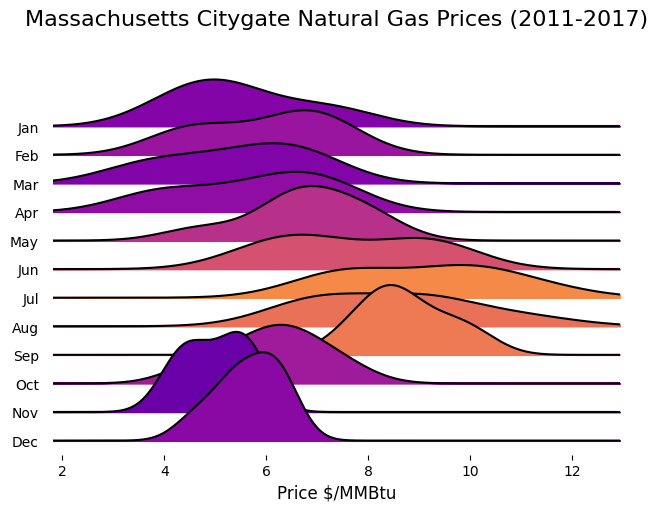

```python
# creating mass_ng_df

from matplotlib import colormaps
from joypy import joyplot

# Assuming 'ng' is your dataframe with Massachusetts prices
mass_ng_df = ng.loc[:, ["Date", "Massachusetts"]]

# Ensure 'Date' is in datetime format
mass_ng_df['Date'] = pd.to_datetime(mass_ng_df['Date'])

# Extract year and month from 'Date'
mass_ng_df['Year'] = mass_ng_df['Date'].dt.year
mass_ng_df['Month'] = mass_ng_df['Date'].dt.month

# transform

# Pivoting the data
mass_ng_ridge = mass_ng_df.pivot(index='Year', columns='Month', values='Massachusetts')

# Rename columns to month names
mass_ng_ridge.columns = ['Jan', 'Feb', 'Mar', 'Apr', 'May', 'Jun',
                         'Jul', 'Aug', 'Sep', 'Oct', 'Nov', 'Dec']

# Reset the index if needed
mass_ng_ridge.reset_index(inplace=True)

# Normalize prices for the color scale
vmin = mass_ng_ridge.iloc[:, 1:].min().min()  # Minimum price
vmax = mass_ng_ridge.iloc[:, 1:].max().max()  # Maximum price

# Create a colormap (e.g., Inferno)
colormap = matplotlib.colormaps['plasma']

# Generate colors for each month based on their mean value
monthly_means = mass_ng_ridge.iloc[:, 1:].mean()
colors = [
    colormap((mean - vmin) / (vmax - vmin))  # Normalize the mean to [0, 1] range
    for mean in monthly_means
]

# Plotting ridgeplot
plt.figure(figsize=(10, 6))
joyplot(
    data=mass_ng_ridge.set_index('Year'),
    column=list(mass_ng_ridge.columns[1:]),
    overlap=1.2,
    kind='kde',
    color=colors  # Apply gradient colors
)

plt.title('Massachusetts Citygate Natural Gas Prices (2011-2017)', fontsize=16)
plt.xlabel('Price $/MMBtu', fontsize=12)
plt.ylabel('Density', fontsize=12)
plt.show()
```

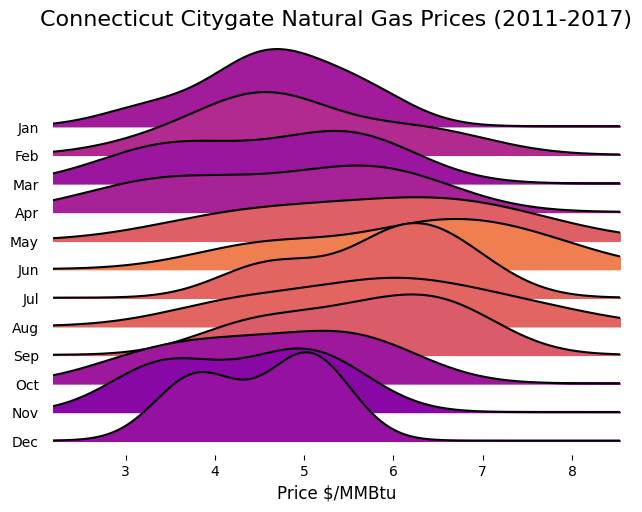

```python
mass_ng_df = ng.loc[:, ["Date", "Connecticut"]]

# Ensure 'Date' is in datetime format
mass_ng_df['Date'] = pd.to_datetime(mass_ng_df['Date'])

# Extract year and month from 'Date'
mass_ng_df['Year'] = mass_ng_df['Date'].dt.year
mass_ng_df['Month'] = mass_ng_df['Date'].dt.month

# transform

# Pivoting the data
mass_ng_ridge = mass_ng_df.pivot(index='Year', columns='Month', values='Connecticut')

# Rename columns to month names
mass_ng_ridge.columns = ['Jan', 'Feb', 'Mar', 'Apr', 'May', 'Jun',
                         'Jul', 'Aug', 'Sep', 'Oct', 'Nov', 'Dec']

# Reset the index if needed
mass_ng_ridge.reset_index(inplace=True)

# Normalize prices for the color scale
vmin = mass_ng_ridge.iloc[:, 1:].min().min()  # Minimum price
vmax = mass_ng_ridge.iloc[:, 1:].max().max()  # Maximum price

# Create a colormap (e.g., Inferno)
colormap = matplotlib.colormaps['plasma']

# Generate colors for each month based on their mean value
monthly_means = mass_ng_ridge.iloc[:, 1:].mean()
colors = [
    colormap((mean - vmin) / (vmax - vmin))  # Normalize the mean to [0, 1] range
    for mean in monthly_means
]

# Plotting ridgeplot
plt.figure(figsize=(10, 6))
joyplot(
    data=mass_ng_ridge.set_index('Year'),
    column=list(mass_ng_ridge.columns[1:]),
    overlap=1.2,
    kind='kde',
    color=colors  # Apply gradient colors
)

plt.title('Connecticut Citygate Natural Gas Prices (2011-2017)', fontsize=16)
plt.xlabel('Price $/MMBtu', fontsize=12)
plt.ylabel('Density', fontsize=12)
plt.show()
```

After plotting citygate prices, we get a result a surprising result. We suspected that gas prices would be higher in the winter, as heating demand takes up a large share of natural gas. However, we see the opposite.

Just looking at citygate gas prices is not enough to detect whether heating demand spills over into the power market. In fact, our chart here shows that there most be some other demand driver in the warmer, summer months that could be pushing up prices. Our results from the citygate results are ambigious -- there doesn't seem to be a consistent trend over time.

Let's check nominal values of gas production, highlighting colder months to see changes. We know that the *generation percentage is changing* but that doesn't neccesary mean that there is a *nominal load change*.

```python
# create a df for just GAS

import warnings
warnings.filterwarnings("ignore", category=pd.errors.SettingWithCopyWarning)

monthly_ng_load = monthly_genmix_nom[['year_month', 'Gas']]

monthly_ng_load.loc[:, 'highlight_month'] = monthly_ng_load['year_month'].dt.month.isin([12, 1, 2])

# Plot for the Nominal Gas Load
gas_chart = alt.Chart(monthly_ng_load).mark_line().encode(
    x=alt.X('year_month:T', title='Month', axis=alt.Axis(format='%b %Y')),
    y=alt.Y('Gas:Q', title='Nominal Gas Load'),
    color=alt.value('blue')
)

# Create a layer to highlight December, January, February
highlight = alt.Chart(monthly_ng_load).mark_point(filled=True, size=100).encode(
    x=alt.X('year_month:T', title='Month', axis=alt.Axis(format='%b %Y')),
    y=alt.Y('Gas:Q', title='Nominal Gas Load'),
    color=alt.value('red'),
    opacity=alt.condition('datum.highlight_month', alt.value(1), alt.value(0))  # Highlight only for Dec, Jan, Feb
)

# Combine both charts
final_chart = gas_chart + highlight

# Display the chart
final_chart.properties(
    title='Nominal Gas Load Over Time with Highlighted Winter Months (Dec, Jan, Feb)',
    width=800,
    height=400
).show()
```

[interactive chart not shown]

We know both nominal gas usage and percentage gas usage is *lower during winter months*. What source of energy is replacing them?

Using our first stacked line chart we do an eye test and identify that coal percentage often spikes during colder weather. We repeat the dual plotting as done above, but now highlighting the local temperature minimum for each year.

```python
from scipy.signal import argrelextrema

# Merge Coal Percentage and Temperature Data
overlay_df = pd.merge(
    monthly_genmix_pct[['year_month', 'Coal Percentage']],
    monthly_temperature,
    on='year_month'
)

# Altair Melt
overlay_long = overlay_df.melt(
    id_vars=['year_month'],
    var_name='Variable',
    value_name='Value'
)

# Chart for Coal Percentage and Temperature
coal_temp = alt.Chart(overlay_long).mark_line().encode(
    x=alt.X('year_month:T', title='Month', axis=alt.Axis(format='%b %Y')),
    y=alt.Y('Value:Q', title='Coal Percentage AND Temperature (Fahrenheit)'),
    color=alt.Color('Variable:N', title='Legend'),
    tooltip=[
        alt.Tooltip('year_month:T', title='Month'),
        alt.Tooltip('Variable:N', title='Variable'),
        alt.Tooltip('Value:Q', title='Value', format='.2f')
    ]
).properties(
    title='Coal Percentage and Temperature Over Time',
    width=800,
    height=400
)

# Identify Local Minima
temperature_values = monthly_temperature['Temperature'].values
local_min_indices = argrelextrema(temperature_values, comparator=np.less, order=3)[0]

# Create a new dataframe for minima points
minima_points = monthly_temperature.iloc[local_min_indices].copy()

# Highlight Minima
highlight_minima = alt.Chart(minima_points).mark_rule(color='red', opacity = 0.3 , strokeWidth = 5).encode(
    x='year_month:T',
    tooltip=[alt.Tooltip('Temperature:Q', title='Temperature')]
)

# Final Chart
final_chart = coal_temp + highlight_minima
final_chart
```

[interactive chart not shown]

By comparing this graph with the Gas graph, we can see that during periods of cold temperature, *coal generation is picking up at least part of the slack*. Further, we note that for most years, the coldest temperature corresponded to the highest generation contribution of coal. Because we know that the nominal share of gas production slows in the winter month, this coal increase could be an indication of spillover, *but* because citygate gas prices do not reflect this, its hard to tell for sure. Further, we don't have exhaustive data on seasonal load patterns and perhaps the share of power used in the summer (to power AC units for example) is so much larger that our winter lows are simply a seasonal effect.

#### Conclusion and Policy Implications

In the second section we then check for spillover effects, specifically looking at the natural gas market through the hypothesis that this heating demand may have also put strain on gas fired generators in the New England ISO. We do not find spillover effects in the price of gas and find ambiguous spillover effects in terms of generation mix and usage. Both nominal and percentage gas usage decrease during the winter periods, but without further context on this usage being scaled relative to summer electricity demanded (which shown by the asymmetries is much higher), this winter dip is hard to attribute to displacement.

Here, further analysis will be needed to explore these spillover effects. While the nominal decrease is an interesting result, it is very likely that because New England uses much more power in the summer, the nominal usage dip in the winter is purely a yearly fixed effects phenomenon, rather than one that supports the hypothesis of heating demand causing a strain for gas-fired power generators. Further, our results from plotting citygate gas prices also point to large summer usage dominating demand strain, rather than winter heating-based demand. We find that citygate gas prices are consistently higher during warmer months and subsequently *cheaper during the winter*.

This research has implications for regions that are in the process of electrifying their heating grid. The energy transition is well underway and as jurisdictions look to replace heating-oil and natural gas based heating systems with electrical systems like heatpumps, having an understanding of how the power market behaves under temperature fluctuations will be key in forecasting power demand.